# DNA Barcode Tutorial

# Gel

Here is a picture of a gel testing the success of the PCR amplification from the 2018 field course. Note that a lot of bands seem to be missing, due to problems with the extraction, PCR, or loading of the samples.

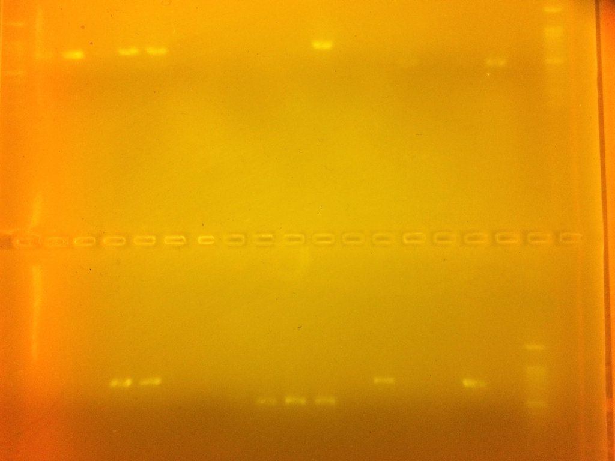

# Download

A list of sequences is below. Let’s start by looking for the link to `1Ipos_F_P1815443_064.ab1` and then download it to your working directory. Note the file code:

- 1-4 is the group number
- I tells us it’s the ITS gene
- F and R tell us whether the gene was sequenced with the Forward or Reverse primer

## ITS genes

- 1I1_F_P1815443_047.ab1
- 1I1_R_P1815443_094.ab1
- 1I2_F_P1815443_048.ab1
- 1I2_R_P1815443_011.ab1
- 1I4_F_P1815443_063.ab1
- 1I4_R_P1815443_012.ab1
- 1Ineg_F_P1815443_079.ab1
- 1Ineg_R_P1815443_028.ab1
- 1Ipos_F_P1815443_064.ab1
- 1Ipos_R_P1815443_027.ab1
- 2I5_F_P1815443_095.ab1
- 2I5_R_P1815443_044.ab1
- 3Ipos_F_P1815443_096.ab1
- 3Ipos_R_P1815443_059.ab1
- 4I4_F_P1815443_029.ab1
- 4I4_R_P1815443_076.ab1
- 4I5_F_P1815443_030.ab1
- 4I5_R_P1815443_091.ab1
- 4I6_F_P1815443_045.ab1
- 4I6_R_P1815443_092.ab1

## rbcL gene

- 1r1_F_P1815443_015.ab1
- 1r1_R_P1815443_062.ab1
- 1r2_F_P1815443_016.ab1
- 1r2_R_P1815443_077.ab1
- 1r4_F_P1815443_031.ab1
- 1r4_R_P1815443_078.ab1
- 1r5_F_P1815443_032.ab1
- 1r5_R_P1815443_093.ab1
- 2r5_F_P1815443_080.ab1
- 2r5_R_P1815443_043.ab1
- 3r2_F_P1815443_013.ab1
- 3r2_R_P1815443_060.ab1
- 3rpos_F_P1815443_014.ab1
- 3rpos_R_P1815443_075.ab1
- 4r5_F_P1815443_046.ab1
- 4r5_R_P1815443_009.ab1
- 4r6_F_P1815443_061.ab1
- 4r6_R_P1815443_010.ab1

# Quality Control

First, inspect the sequencing statistics. What data do you think each of the columns are showing?

- Well
- Chromatogram
- Sample
- DNA Type
- Submission Lot
- Project
- Primer
- DNA Type - Template Size
- Comment
- Length
- Score
- Capilary
- Ok

Next, we will use an R package called `sangerseqR` inspect the chromatograph, sometimes called the ‘trace’ file. To make sense of the chromatograph you should **review how Sanger Sequencing works**.

The `sangerseqR` package is part of the **bioconductor** package for R, which has a lot of great tools for analyzing ‘omics’ data. For more information, check out the [bioconductor website](https://www.bioconductor.org/).

There are a lot of packages, so we’ll just install the sangerseqR package rather than trying to install everything in bioconductor.

```r
source("https://bioconductor.org/biocLite.R")
biocLite(c("sangerseqR"))
```

Now load the library and read in the sequence for your sample:

```r
library(sangerseqR)
rbcL<-read.abif("./Data/DNA_Barcoding/ITS/1Ipos_F_P1815443_064.ab1")
```

We convert the ab1 file to a Sangerseq object using the `sangerseq()` function and inspect the structure of the data file

```r
rbcLseq <- sangerseq(rbcL)
str(rbcLseq)
```

```
## Formal class 'sangerseq' [package "sangerseqR"] with 7 slots
##   ..@ primarySeqID  : chr "From ab1 file"
##   ..@ primarySeq    :Formal class 'DNAString' [package "Biostrings"] with 5 slots
##   .. .. ..@ shared         :Formal class 'SharedRaw' [package "XVector"] with 2 slots
##   .. .. .. .. ..@ xp                    :<externalptr>
##   .. .. .. .. ..@ .link_to_cached_object:<environment: 0x0000000022598c78>
##   .. .. ..@ offset         : int 0
##   .. .. ..@ length         : int 1244
##   .. .. ..@ elementMetadata: NULL
##   .. .. ..@ metadata       : list()
##   ..@ secondarySeqID: chr "From ab1 file"
##   ..@ secondarySeq  :Formal class 'DNAString' [package "Biostrings"] with 5 slots
##   .. .. ..@ shared         :Formal class 'SharedRaw' [package "XVector"] with 2 slots
##   .. .. .. .. ..@ xp                    :<externalptr>
##   .. .. .. .. ..@ .link_to_cached_object:<environment: 0x0000000022598c78>
##   .. .. ..@ offset         : int 0
##   .. .. ..@ length         : int 0
##   .. .. ..@ elementMetadata: NULL
##   .. .. ..@ metadata       : list()
##   ..@ traceMatrix   : int [1:14869, 1:4] 0 0 0 0 0 0 0 0 0 0 ...
##   ..@ peakPosMatrix : num [1:1244, 1:4] 194 204 214 224 235 245 256 267 279 290 ...
##   ..@ peakAmpMatrix : logi [1, 1:4] NA NA NA NA
```

This is an example of a ‘class object’. You can see the `@` to denote different elements of the object. This is similar to the way that `$` denotes a column in a data.frame object. These are called ‘slots’ and can be used to subset the class object the same way `$` can subset the data.fram object.

```r
rbcLseq@primarySeqID
```

```
## [1] "From ab1 file"
```

```r
rbcLseq@primarySeq
```

```
##   1244-letter "DNAString" instance
## seq: CGGTNANGAGTCTTTGACGCAGTTGCGCCCCAAG...NNNNNNNNNNNNNNNNNNNNNNNNNNNNNNNNN
```

Here is an overview of the main slot elements:

- **primarySeqID** – Identification of the primary sequence
- **primarySeq** – The most likely sequence based on the florescence pattern
- **secondarySeqID** – Secondary sequence ID. Secondary calls may not be present, but can occur when there is a signal for more than one base pair
- **secondarySeq** – The secondary sequence
- **traceMatrix** – A matrix containing the normalized signals for A,C,G,T.
- **peakPosMatrix** – A matrix containing the position of the maximum peak values for each base.
- **peakAmpMatrix** A matrix containing the maximum peak amplitudes for each base.

Now we can graph the trace.

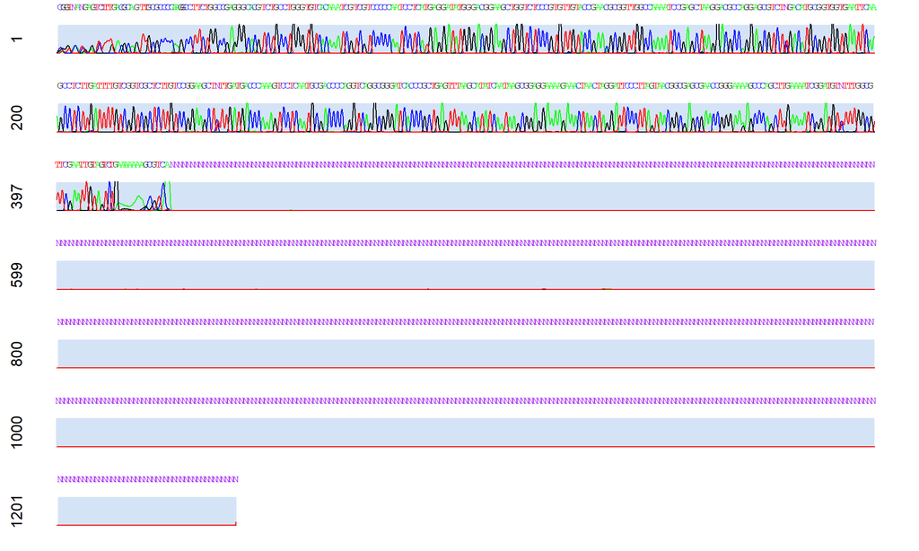

```r
chromatogram(rbcLseq, width = 200, height = 2, showcalls = "both")
```

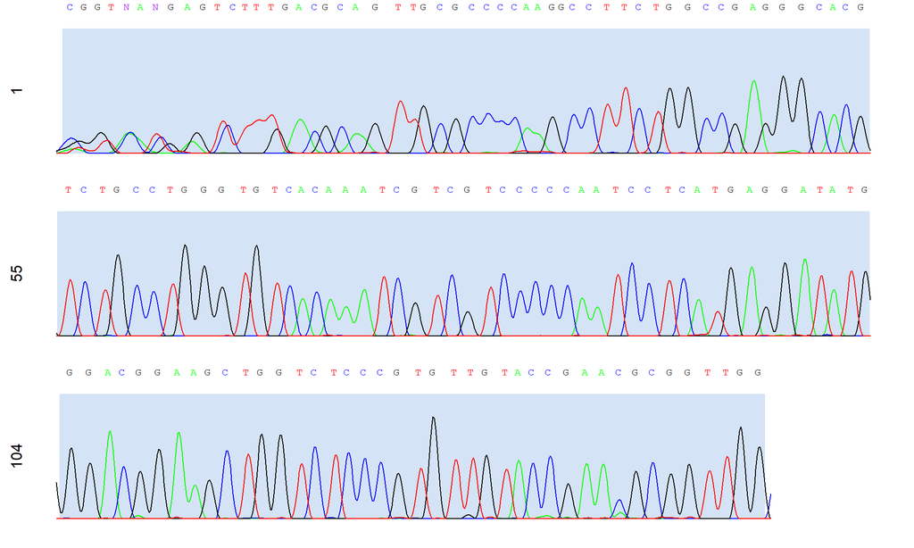

```r
chromatogram(rbcLseq, width = 50, height = 2, trim3=1100, showcalls = "both")
```

What do you notice about the early part of the sequence?

Play around with the parameters until you have a good sequence. You may want to use the `filename=graph.pdf` parameter to save the graph to a pdf file that makes it easier to zoom in and inspect the graph.

A quick and easy method is to use the `MakeBaseCalls()` functions to ‘call’ the base pairs based on the strongest signals.

```r
makeBaseCalls(rbcLseq)
```

```
## Number of datapoints: 14869
## Number of basecalls: 676
##
## Primary Basecalls: CGGTCTGAGTCTTACGCAGTTGCGCCCCATGCCTTCTGGCCGAGGGCACGTCTGCCTGGG…
##
## Secondary Basecalls: CTGTACGAGTCTGACGCAGTTGCGCCCCATGCCTTCTGGCCGAGGGCACGTCTGCCTGGG…
```

# BLAST

BLAST stand for Basic Local Alignment Search Tool, and there is a nice web interface for it at the address https://blast.ncbi.nlm.nih.gov/Blast.cgi

Take a moment to **note the different types of BLAST**. Why do you think there are so many different types?

We are using genes with fairly low mutation rates, so BLASTn is appropriate for finding a species-level match.

Simply copy and paste the sequence above into the sequence search box and you are ready to go!